# Assignment #1

## Questions & Answers

#### Q1. What are the control and test conditions of the dataset?

A: This test is gene expression profiling of MDA231, BT549 and SUM159PT cells after selumetinib treatment or DUSP4 siRNA knockdown. The control elements are MDA231, BT549 and SUM159PT basasl-like breast cancer cell lines. The case elements are the transfected of those control elements with siRNA targeting DUSP4 or 4 or 24 hr of 1uM selumetinib.

#### Q2. Why is the dataset of interest to you?

A: The rearch is talking about basal-like breast cancer which is a disease that lacks clinically approved targeted therapy.

#### Q4. Were ther expression values that could not be mapped to current HUGO symbols?

A: I have many probe ids that cannot find the corresponding HUGO symbols from the gene database.

#### Q5. How many outliers were removed?

A: I don’t remove any outliers, the most I have done is to filter the values that duplicated and cannot map to the HUGO symbols.

#### Q6. How did you handle replicates?

A: I remove the replicates, only save the unique symbols and corresponding values in my final result.

## Reference

1. https://github.com/bcb420-2020/General_Course_Info/wiki/Assignment%231#Select_an_Expression_Data_Set
2. https://www.ncbi.nlm.nih.gov/geo/info/geo2r.html#how_to_use
3. https://www.ncbi.nlm.nih.gov/geo/query/acc.cgi?acc=GSE41816
4. https://risserlin.github.io/BCB420-lectures-public/lecture4_data_exploration_and_normalization.html#1
5. https://www.ncbi.nlm.nih.gov/pubmed/23966295
6. http://bioconductor.org/packages/release/data/annotation/html/hugene11sttranscriptcluster.db.html

## Code & Output

```r
library(GEOquery)
library(Biobase)
library(limma)
```

```r
library(edgeR)

#load data
# load origin data without mapping and clean duplicates
gset <- getGEO("GSE41816", GSEMatrix =TRUE, getGPL=FALSE)
```

```
## Found 1 file(s)
```

```
## GSE41816_series_matrix.txt.gz
```

```r
if (length(gset) > 1) idx <- grep("GPL11532", attr(gset, "names")) else idx <- 1
gset <- gset[[idx]]
save(gset, file = 'GSE41816_matrix.Rdata')

gse <- getGEO('GSE41816', destdir = ".",
               AnnotGPL = FALSE,
               getGPL = FALSE)
```

```
## Found 1 file(s)
```

```
## GSE41816_series_matrix.txt.gz
```

```
## Using locally cached version: ./GSE41816_series_matrix.txt.gz
```

```r
exp <- read.table(file = 'GSE41816_series_matrix.txt.gz',
                      sep = '\t',
                      header = TRUE,
                      quote = '',
                      fill = TRUE,
                      comment.char = "!")
exp0 <- exp
# save
save(exp0, file = 'exp_GSE41816.Rdata')
```

```r
#GSE41816
# load the data
load("exp_GSE41816.Rdata")
# change the row names into probe_id
rownames(exp0) <- exp0[, 1]

# loading the database contain the HUGO symbols
library(hugene11sttranscriptcluster.db)
# load probe_ids and symbols
ids <- toTable(hugene11sttranscriptclusterSYMBOL)
# number of unique symbols
length(unique(ids$symbol))
```

```
## [1] 18832
```

```r
# load probe_ids and ensembl ids
ensembl <- toTable(hugene11sttranscriptclusterENSEMBL)
# number of unique ensembl ids
length(unique(ensembl$ensembl_id))
```

```
## [1] 20212
```

```r
table(rownames(exp0) %in% ids$probe_id)
```

```
##
## FALSE  TRUE
## 13472 19825
```

```r
# save exists probe_ids in table according to HUGO database
# only mapped genes can be saved
exp0 <- exp0[rownames(exp0) %in% ids$probe_id,]

# reduce the duplicated symbols, choose the max value in the row
tmp <- by(exp0,
         ids$symbol,
         function(x) rownames(x)[which.max(rowMeans(x))])

probes <- as.character(tmp)
# filter again, leave unique symbols in the table
exp0 <- exp0[rownames(exp0) %in% probes,]

ids <- ids[match(rownames(exp0), ids$probe_id),]
ensembl <- ensembl[match(rownames(exp0), ensembl$probe_id),]
# change the row names into symbols
rownames(exp0) <- ids$symbol
# add new column to save ensembl ids
exp0$X.Ensembl_ID <- ensembl$ensembl_id
exp1 <- exp0
# save into my local folder
# exp1 contains the final result after mapping and clean
save(exp1, file = 'exp_GSE41816_id_trans.Rdata')
```

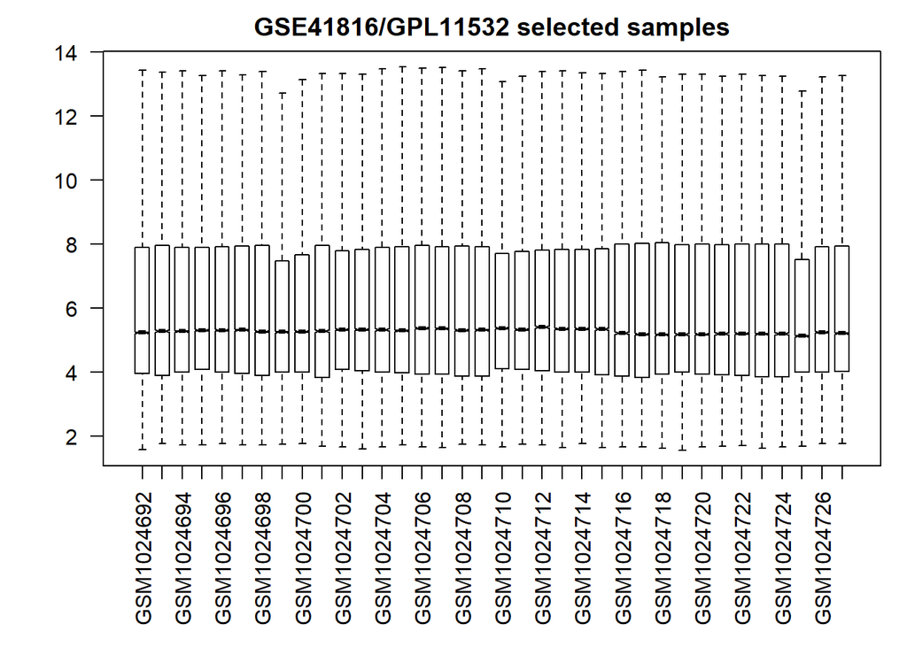

```r
# load data after mapping and clean
load("exp_GSE41816_id_trans.Rdata")
# load data as matrix
load("GSE41816_matrix.Rdata")

# Plots
# boxplot for original data from GEO database
par(mar=c(2+round(max(nchar(sampleNames(gset)))/2),4,2,1))
title <- paste ("GSE41816", '/', annotation(gset), " selected samples", sep ='')
boxplot(exprs(gset), boxwex=0.7, notch=T, main=title, outline=FALSE, las=2)
```

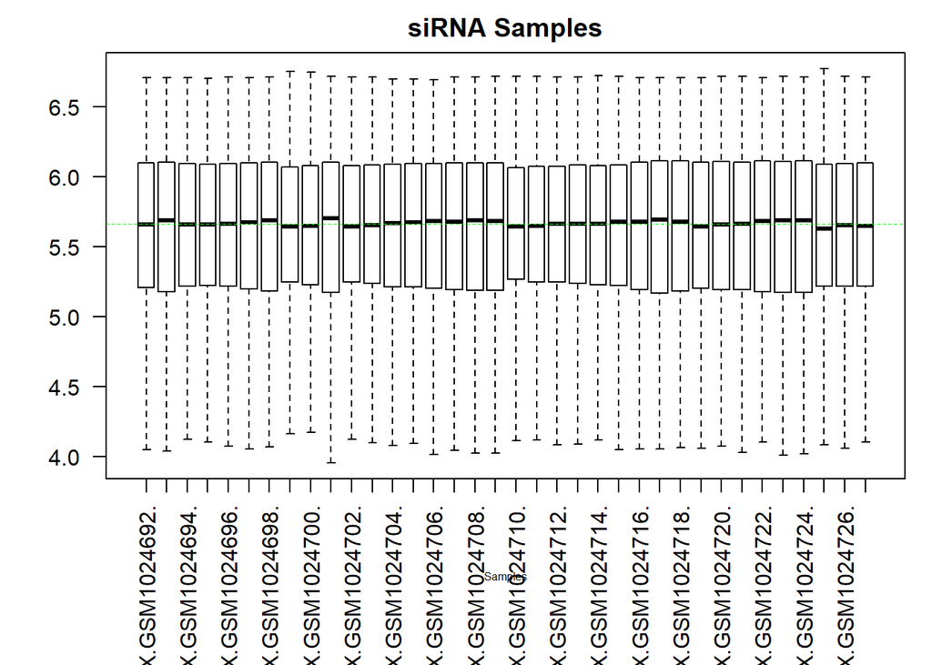

```r
# boxplot after normalized
# log ratio for the genes after mapping and clean
d2p <- log2(cpm(exp1[, 2:37]))
boxplot(d2p, xlab = "Samples", tlab = "log2",
        las = 2, cex = 0.5, cex.lab = 0.5,
        cex.aixs = 0.5, main = "siRNA Samples")
abline(h = median(apply(d2p, 2, median)),
       col = "green", lwd = 0.6, lty = "dashed")
```

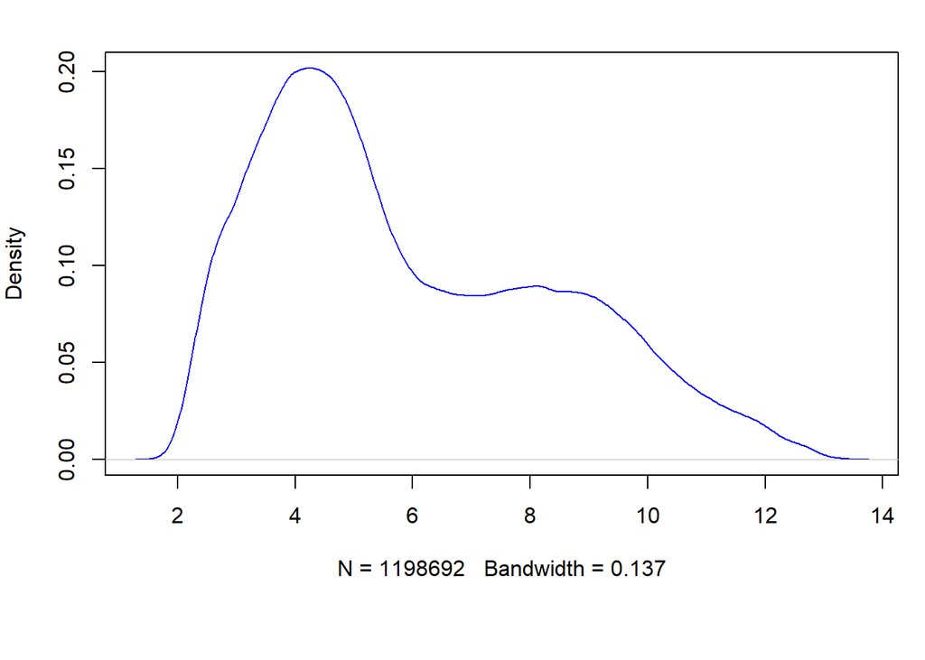

```r
# using normalize.quantiles to have a plot
library(preprocessCore)
GSE41816 <- normalize.quantiles(exprs(gset))
plot(density(GSE41816), col = "blue", main = "")
```

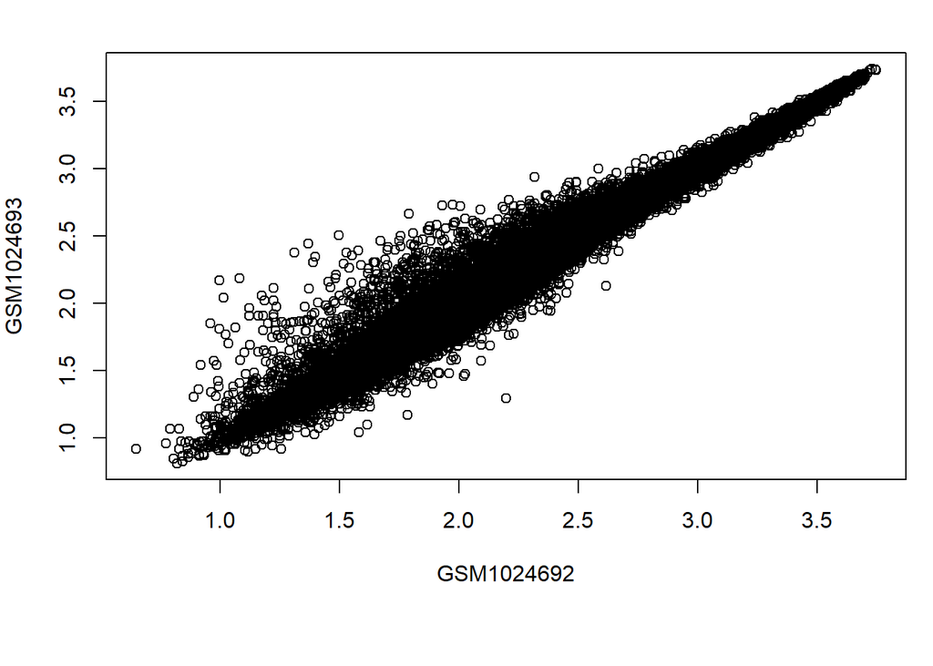

```r
GSE41816log <- log2(exprs(gset))
plot(GSE41816log)
```

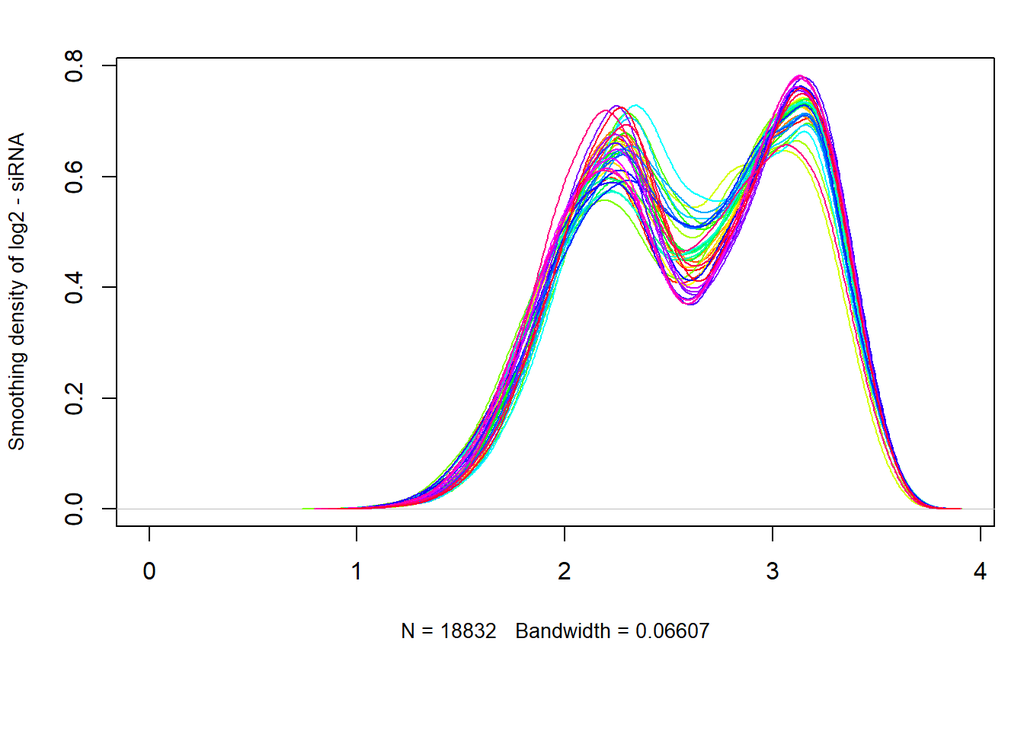

```r
# Density plot with log2()
count_density <- apply(log2(exp1[, 2:37]), 2, density)

xlim <- 0; ylim <- 0
for(i in 1:length(count_density)) {
  xlim <- range(c(xlim, count_density[[i]]$x));
  ylim <- range(c(ylim, count_density[[i]]$y));
}

cols <- rainbow(length(count_density))
ltys <- rep(1, length(count_density))

plot(count_density[[1]], xlim = xlim, ylim = ylim,
     type = "n", ylab = "Smoothing density of log2 - siRNA",
     main = "", cex.lab = 0.85)

for (i in 1:length(count_density)) {
  lines(count_density[[i]], col = cols[i], lty = ltys[i])
}
```

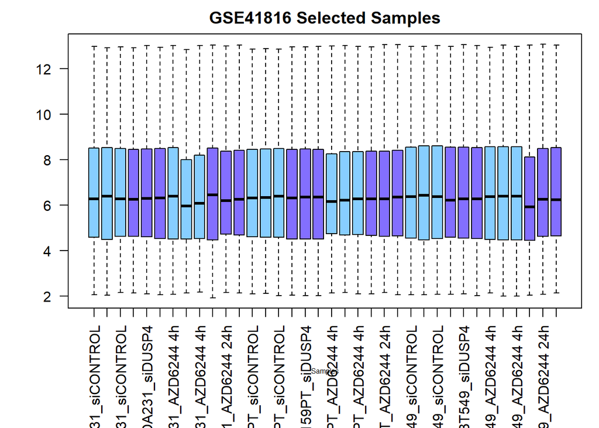

```r
# Separate into groups
group_list <- c(rep('MDA231_siCONTROL', 3), rep('MDA231_siDUSP4', 3),
                rep('MDA231_AZD6244 4h', 3), rep('MDA231_AZD6244 24h', 3),
                rep('SUM159PT_siCONTROL', 3), rep('SUM159PT_siDUSP4', 3),
                rep('SUM159PT_AZD6244 4h', 3), rep('SUM159PT_AZD6244 24h', 3),
                rep('BT549_siCONTROL', 3), rep('BT549_siDUSP4', 3),
                rep('BT549_AZD6244 4h', 3), rep('BT549_AZD6244 24h', 3))
# remove gene symbol and ensembl id
exp2 <- exp1[2:37]
colnames(exp2) <- rep(group_list, ncol(exp2)/36)
# exp2 defined groups

# boxplot by defined groups
boxplot(exp2, xlab = "Samples", tlab = "Values",
        las = 2, cex = 0.5, cex.lab = 0.5,
        cex.aixs = 0.5, main = "GSE41816 Selected Samples",
        col = c(rep("skyblue1", 3), rep("slateblue1", 3)))
```

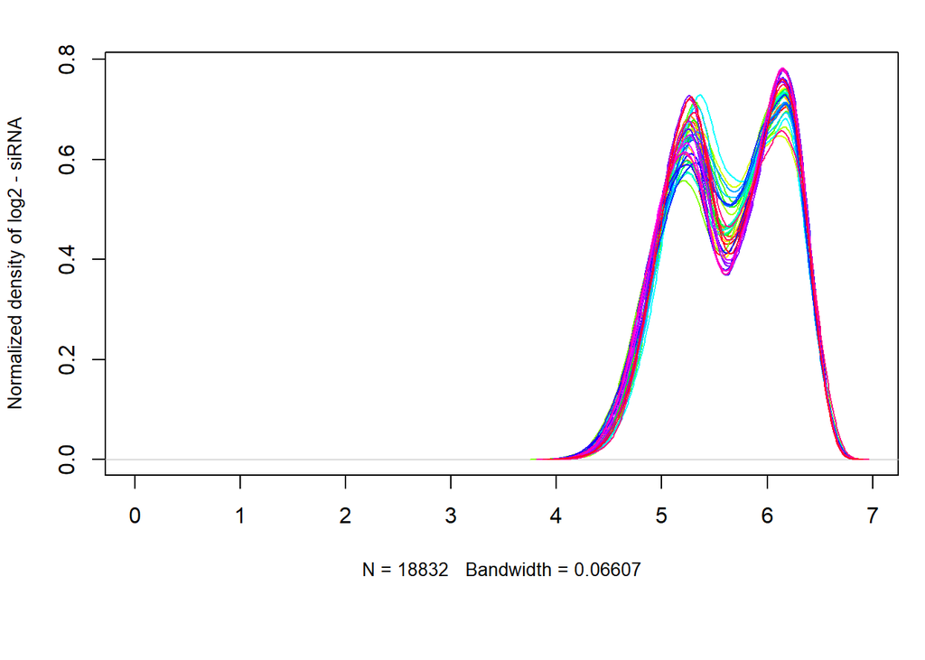

```r
filter_matrix <- as.matrix(exp1[, 2:37])
rownames(filter_matrix) <- exp1[,38]
d = DGEList(counts = filter_matrix, group = colnames(exp2))
# get normalized data by cpm()
nor_counts <- cpm(d)

# density plot after normalized by defined groups
cd1 <- apply(log2(nor_counts), 2, density)

xlim1 <- 0; ylim1 <- 0
for(i in 1:length(cd1)) {
  xlim1 <- range(c(xlim1, cd1[[i]]$x));
  ylim1 <- range(c(ylim1, cd1[[i]]$y));
}

cols1 <- rainbow(length(cd1))
ltys1 <- rep(1, length(cd1))

plot(cd1[[1]], xlim = xlim1, ylim = ylim1,
     type = "n", ylab = "Normalized density of log2 - siRNA",
     main = "", cex.lab = 0.85)

for (i in 1:length(cd1)) {
  lines(cd1[[i]], col = cols1[i], lty = ltys1[i])
}
```